# 2.A. Population Structure and Relatedness Inference

Population structure due to genetic ancestry and genetic correlation due to sample relatedness are important factors to consider when performing association tests as their presence can lead to mis-calibration of test statistics and false positive associations. This tutorial demonstrates how to perform population structure and relatedness inference using the [GENESIS](https://bioconductor.org/packages/release/bioc/html/GENESIS.html) and [SNPRelate](https://www.bioconductor.org/packages/release/bioc/html/SNPRelate.html) R/Bioconductor packages. We use the results of this inference to perform association tests in the GWAS tutorials.

For this tutorial we have provide a GDS file combined across all chromosomes and filtered to common variants with minor allele frequency (MAF) $> 5\%$ in the sample.

## LD-pruning

We generally advise that population structure and relatedness inference be performed using a set of (nearly) independent genetic variants. To find this set of variants, we perform linkage-disequilibrium (LD) pruning on the study sample set. We typically use an LD threshold of `r^2 < 0.1` to select variants. We use the SNPRelate package to perform LD-pruning with GDS files.

```r
library(SeqArray)
repo_path <- "https://github.com/UW-GAC/SISG_2024/raw/main"

# use a GDS file with all chromosomes
if (!dir.exists("data")) dir.create("data")
gdsfile <- "data/1KG_phase3_GRCh38_subset_maf05_ALL_chr.gds"
if (!file.exists(gdsfile)) download.file(file.path(repo_path, gdsfile), gdsfile)
gdsfmt::showfile.gds(closeall=TRUE) # make sure file is not already open
gds <- seqOpen(gdsfile)

# run LD pruning
library(SNPRelate)
set.seed(100) # LD pruning has a random element; so make this reproducible
snpset <- snpgdsLDpruning(gds,
                          maf = 0.01,
                          ld.threshold=sqrt(0.1))
```

```
## SNV pruning based on LD:
## Calculating allele counts/frequencies ...
##
[..................................................]  0%, ETC: ---
[==================================================] 100%, completed, 3s
## # of selected variants: 305,768
##     # of samples: 1,040
##     # of SNVs: 305,768
##     using 1 thread
##     sliding window: 500,000 basepairs, Inf SNPs
##     |LD| threshold: 0.316228
##     method: composite
## Chromosome 1: 35.23%, 4,412/12,525
## Chromosome 2: 32.00%, 4,308/13,461
## Chromosome 3: 25.45%, 4,208/16,534
## Chromosome 4: 20.79%, 4,047/19,463
## Chromosome 5: 29.29%, 3,910/13,349
## Chromosome 6: 24.22%, 3,852/15,902
## Chromosome 7: 32.08%, 3,794/11,826
## Chromosome 8: 25.57%, 3,641/14,242
## Chromosome 9: 26.08%, 3,551/13,615
## Chromosome 10: 28.30%, 3,731/13,185
## Chromosome 11: 26.79%, 3,459/12,913
## Chromosome 12: 25.16%, 3,689/14,663
## Chromosome 13: 21.49%, 3,160/14,703
## Chromosome 14: 24.79%, 3,036/12,246
## Chromosome 15: 19.98%, 3,175/15,887
## Chromosome 16: 23.86%, 3,238/13,569
## Chromosome 17: 26.51%, 3,077/11,608
## Chromosome 18: 18.99%, 3,153/16,603
## Chromosome 19: 24.71%, 2,908/11,769
## Chromosome 20: 22.91%, 2,818/12,302
## Chromosome 21: 17.48%, 2,245/12,844
## Chromosome 22: 18.56%, 2,331/12,559
## 75,743 markers are selected in total.
```

```r
# how many variants on each chr?
sapply(snpset, length)
```

```
##  chr1  chr2  chr3  chr4  chr5  chr6  chr7  chr8  chr9 chr10 chr11 chr12 chr13
##  4412  4308  4208  4047  3910  3852  3794  3641  3551  3731  3459  3689  3160
## chr14 chr15 chr16 chr17 chr18 chr19 chr20 chr21 chr22
##  3036  3175  3238  3077  3153  2908  2818  2245  2331
```

```r
# get the full list of LD-pruned variants
pruned <- unlist(snpset, use.names=FALSE)
length(pruned)
```

```
## [1] 75743
```

## Computing a GRM

We can use the SNPRelate package to compute a Genetic Relationship matrix (GRM) using GDS files. A GRM captures genetic correlation among samples due to both distant ancestry (i.e. population structure) and recent kinship (i.e. familial relatedness) in a single matrix.

SNPRelate offers several algorithms for computing a GRM, including the commonly-used GCTA [Yang et al 2011](https://www.ncbi.nlm.nih.gov/pubmed/21167468) (`method = "GCTA"`) and allelic matching based estimators described by [Weir and Goudet 2017](https://www.ncbi.nlm.nih.gov/pubmed/28550018) (`method = "IndivBeta"`).

```r
# compute the GRM using the GCTA method
library(SNPRelate)
grm <- snpgdsGRM(gds, method="GCTA", snp.id = pruned)
```

```
## Genetic Relationship Matrix (GRM, GCTA):
## Calculating allele counts/frequencies ...
##
[..................................................]  0%, ETC: ---
[==================================================] 100%, completed, 2s
## # of selected variants: 75,743
##     # of samples: 1,040
##     # of SNVs: 75,743
##     using 1 thread
## CPU capabilities:
## Mon Jun  3 19:07:49 2024    (internal increment: 472)
##
[..................................................]  0%, ETC: ---
[==================================================] 100%, completed, 41s
## Mon Jun  3 19:08:30 2024    Done.
```

```r
names(grm)
```

```
## [1] "sample.id" "snp.id"    "method"    "grm"
```

```r
dim(grm$grm)
```

```
## [1] 1040 1040
```

```r
# look at the top corner of the matrix
grm$grm[1:5,1:5]
```

```
##            [,1]       [,2]       [,3]       [,4]       [,5]
## [1,] 0.94936208 0.07507070 0.08290501 0.07041950 0.07981302
## [2,] 0.07507070 0.95193999 0.06952752 0.08517712 0.07612110
## [3,] 0.08290501 0.06952752 0.94074070 0.09478942 0.08585627
## [4,] 0.07041950 0.08517712 0.09478942 0.94634467 0.09946362
## [5,] 0.07981302 0.07612110 0.08585627 0.09946362 0.94186583
```

## De-convoluting ancestry and relatedness

To disentangle distant ancestry (i.e. population structure) from recent kinship (i.e. familial relatedness), we implement the analysis described in Conomos et al., 2016. This approach uses the [KING-robust](http://www.ncbi.nlm.nih.gov/pubmed/20926424), [PC-AiR](http://www.ncbi.nlm.nih.gov/pubmed/25810074), and [PC-Relate](http://www.ncbi.nlm.nih.gov/pubmed/26748516) methods.

### KING-robust

Step 1 is to get initial kinship estimates using [KING-robust](http://www.ncbi.nlm.nih.gov/pubmed/20926424), which is robust to discrete population structure but not ancestry admixture. KING-robust will be able to identify close relatives (e.g. 1st and 2nd degree) reliably, but may identify spurious pairs or miss more distant pairs of relatives in the presence of admixture. KING is available as its own software, but the KING-robust algorithm is also available in SNPRelate via the function `snpgdsIBDKING`.

```r
# run KING-robust
king <- snpgdsIBDKING(gds, snp.id=pruned)
```

```
## IBD analysis (KING method of moment) on genotypes:
## Calculating allele counts/frequencies ...
##
[..................................................]  0%, ETC: ---
[==================================================] 100%, completed, 2s
## # of selected variants: 75,743
##     # of samples: 1,040
##     # of SNVs: 75,743
##     using 1 thread
## No family is specified, and all individuals are treated as singletons.
## Relationship inference in the presence of population stratification.
## CPU capabilities:
## Mon Jun  3 19:08:33 2024    (internal increment: 15104)
##
[..................................................]  0%, ETC: ---
[==================================================] 100%, completed, 4s
## Mon Jun  3 19:08:37 2024    Done.
```

```r
names(king)
```

```
## [1] "sample.id" "snp.id"    "afreq"     "IBS0"      "kinship"
```

```r
# extract the kinship estimates
kingMat <- king$kinship
colnames(kingMat) <- rownames(kingMat) <- king$sample.id
dim(kingMat)
```

```
## [1] 1040 1040
```

```r
# look at the top corner of the matrix
kingMat[1:5,1:5]
```

```
##            HG00096    HG00097    HG00099    HG00100    HG00101
## HG00096 0.50000000 0.01407729 0.01878175 0.01381189 0.02020718
## HG00097 0.01407729 0.50000000 0.01040445 0.02046941 0.01361374
## HG00099 0.01878175 0.01040445 0.50000000 0.02828253 0.02300703
## HG00100 0.01381189 0.02046941 0.02828253 0.50000000 0.03461278
## HG00101 0.02020718 0.01361374 0.02300703 0.03461278 0.50000000
```

We extract pairwise kinship estimates and IBS0 values (the proportion of variants for which the pair of indivdiuals share 0 alleles identical by state) to plot. We use a hexbin plot to visualize the relatedness for all pairs of samples.

```r
kinship <- snpgdsIBDSelection(king)
head(kinship)
```

```
##       ID1     ID2       IBS0    kinship
## 1 HG00096 HG00097 0.04726509 0.01407729
## 2 HG00096 HG00099 0.04659176 0.01878175
## 3 HG00096 HG00100 0.04693503 0.01381189
## 4 HG00096 HG00101 0.04587883 0.02020718
## 5 HG00096 HG00102 0.04582602 0.01819071
## 6 HG00096 HG00103 0.04657856 0.01417400
```

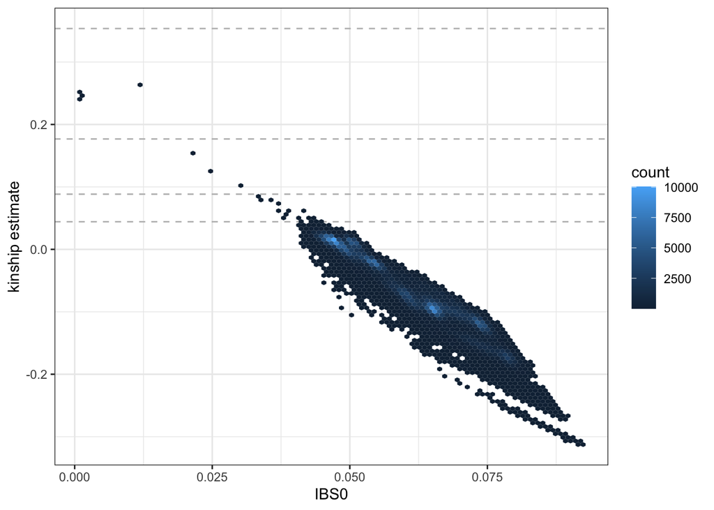

```r
library(ggplot2)
ggplot(kinship, aes(IBS0, kinship)) +
    geom_hline(yintercept=2^(-seq(3,9,2)/2), linetype="dashed", color="grey") +
    geom_hex(bins = 100) +
    ylab("kinship estimate") +
    theme_bw()
```

We see a few parent-offspring, full sibling, 2nd degree, and 3rd degree relative pairs. The abundance of negative estimates represent pairs of individuals who have ancestry from different populations – the magnitude of the negative relationship is informative of how different their ancestries are; more on this below.

### PC-AiR

The next step is [PC-AiR](http://www.ncbi.nlm.nih.gov/pubmed/25810074), which provides robust population structure inference in samples with kinship and pedigree structure. PC-AiR is available in the GENESIS package via the function `pcair`.

First, PC-AiR partitions the full sample set into a set of mutually unrelated samples that is maximally informative about all ancestries in the sample (i.e. the unrelated set) and their relatives (i.e. the related set). We use a 3rd degree kinship threshold (`kin.thresh = 2^(-9/2)`), which corresponds to first cousins – this defines anyone less related than first cousins as “unrelated”. We use the negative KING-robust estimates as “ancestry divergence” measures (`divMat`) to identify pairs of samples with different ancestry – we preferentially select individuals with many negative estimates for the unrelated set to ensure ancestry representation. For now, we also use the KING-robust estimates as our kinship measures (`kinMat`); more on this below.

Once the unrelated and related sets are identified, PC-AiR performs a standard Principal Component Analysis (PCA) on the unrelated set of individuals and then projects the relatives onto the PCs. Under the hood, PC-AiR uses the SNPRelate package for efficient PC computation and projection.

```r
# run PC-AiR
library(GENESIS)
pca <- pcair(gds,
            kinobj = kingMat,
            kin.thresh = 2^(-9/2),
            divobj = kingMat,
            div.thresh = -2^(-9/2),
            snp.include = pruned)
```

```
## Using kinobj and divobj to partition samples into unrelated and related sets
```

```
## Working with 1040 samples
```

```
## Identifying relatives for each sample using kinship threshold 0.0441941738241592
```

```
## Identifying pairs of divergent samples using divergence threshold -0.0441941738241592
```

```
## Partitioning samples into unrelated and related sets...
```

```
## Unrelated Set: 1014 Samples
## Related Set: 26 Samples
```

```
## Performing PCA on the Unrelated Set...
```

```
## Principal Component Analysis (PCA) on genotypes:
## Calculating allele counts/frequencies ...
##
[..................................................]  0%, ETC: ---
[==================================================] 100%, completed, 2s
## # of selected variants: 75,743
##     # of samples: 1,014
##     # of SNVs: 75,743
##     using 1 thread
##     # of principal components: 32
## CPU capabilities:
## Mon Jun  3 19:08:42 2024    (internal increment: 484)
##
[..................................................]  0%, ETC: ---
[==================================================] 100%, completed, 40s
## Mon Jun  3 19:09:22 2024    Begin (eigenvalues and eigenvectors)
## Mon Jun  3 19:09:23 2024    Done.
```

```
## Predicting PC Values for the Related Set...
```

```
## SNP Loading:
##     # of samples: 1,014
##     # of SNPs: 75,743
##     using 1 thread
##     using the top 32 eigenvectors
## Mon Jun  3 19:09:23 2024    (internal increment: 3876)
##
[..................................................]  0%, ETC: ---
[==================================================] 100%, completed, 3s
## Mon Jun  3 19:09:26 2024    Done.
## Sample Loading:
##     # of samples: 26
##     # of SNPs: 75,743
##     using 1 thread
##     using the top 32 eigenvectors
## Mon Jun  3 19:09:26 2024    (internal increment: 65536)
##
[..................................................]  0%, ETC: ---
[==================================================] 100%, completed, 2s
## Mon Jun  3 19:09:28 2024    Done.
```

```r
names(pca)
```

```
##  [1] "vectors"    "values"     "rels"       "unrels"     "kin.thresh"
##  [6] "div.thresh" "sample.id"  "nsamp"      "nsnps"      "varprop"
## [11] "call"       "method"
```

```r
# the unrelated set of samples
length(pca$unrels)
```

```
## [1] 1014
```

```r
head(pca$unrels)
```

```
## [1] "HG00096" "HG00097" "HG00099" "HG00100" "HG00101" "HG00102"
```

```r
# the related set of samples
length(pca$rels)
```

```
## [1] 26
```

```r
head(pca$rels)
```

```
## [1] "NA20278" "NA20900" "NA20274" "NA20299" "NA19661" "NA19657"
```

```r
# extract the top 12 PCs and make a data.frame
pcs <- data.frame(pca$vectors[,1:12])
colnames(pcs) <- paste0('PC', 1:12)
pcs$sample.id <- pca$sample.id
dim(pcs)
```

```
## [1] 1040   13
```

```r
head(pcs)
```

```
##                PC1         PC2        PC3         PC4           PC5         PC6
## HG00096 0.01800549 -0.03361957 0.01541131 -0.02085591 -0.0037719379 -0.04669896
## HG00097 0.01742309 -0.03361182 0.01304470 -0.01992104 -0.0095947596 -0.04545408
## HG00099 0.01799001 -0.03418633 0.01152677 -0.01694420  0.0011408340 -0.05178681
## HG00100 0.01793750 -0.03378008 0.01491137 -0.01954784  0.0045447134 -0.04375806
## HG00101 0.01759459 -0.03318057 0.01568040 -0.01892110 -0.0009236657 -0.05762760
## HG00102 0.01796459 -0.03344242 0.01286241 -0.01767438  0.0022747910 -0.06528352
##                PC7          PC8         PC9          PC10         PC11
## HG00096 0.01985608  0.008985902 0.026996901  0.0041579044 -0.003803835
## HG00097 0.01034344  0.025550498 0.011886491 -0.0223288469 -0.020732328
## HG00099 0.02212758  0.012950846 0.028599645 -0.0046117845 -0.004731816
## HG00100 0.02055287 -0.012583055 0.003434313  0.0106009372  0.007842334
## HG00101 0.03443987  0.018017382 0.022045858  0.0003858169 -0.007009917
## HG00102 0.03392455  0.015166974 0.006720184  0.0019921179  0.001414767
##                 PC12 sample.id
## HG00096  0.011771859   HG00096
## HG00097  0.002096803   HG00097
## HG00099  0.004180146   HG00099
## HG00100  0.006986524   HG00100
## HG00101 -0.005164265   HG00101
## HG00102  0.003916856   HG00102
```

```r
# save output
save(pcs, file="data/pcs.RData")
```

We’d like to determine which PCs are ancestry informative. To do this we look at the PCs in conjunction with reported population information for the 1000 Genomes samples. This information is stored in the provided `pheno_data.tsv` file. We make a parallel coordinates plot and pairwise scatter plots, color-coding samples by 1000 Genomes population labels.

```r
phenfile <- "data/pheno_data.tsv"
if (!file.exists(phenfile)) download.file(file.path(repo_path, phenfile), phenfile)
phen <- read.table(phenfile, header = TRUE, sep = "\t", as.is = TRUE)
head(phen)
```

```
##   sample.id pop super_pop    sex age trait_1 trait_2 status
## 1   HG00096 GBR       EUR   male  56    23.5     0.1      0
## 2   HG00097 GBR       EUR female  56    23.9     0.1      0
## 3   HG00099 GBR       EUR female  48    23.8     0.3      0
## 4   HG00100 GBR       EUR female  54    24.9     0.2      0
## 5   HG00101 GBR       EUR   male  65    27.6     0.7      1
## 6   HG00102 GBR       EUR female  53    24.5     0.4      0
```

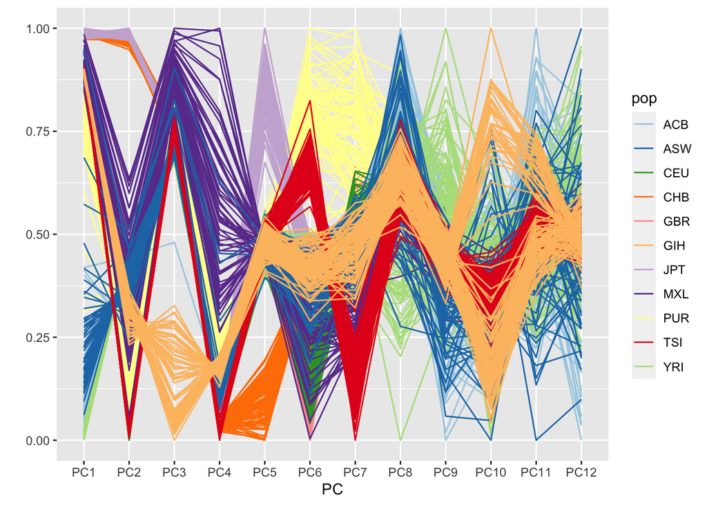

```r
pc.df <- merge(pcs, phen[,c("sample.id", "pop")], by = "sample.id")

library(GGally)
library(RColorBrewer)
pop.cols <- setNames(brewer.pal(12, "Paired"),
                 c("ACB", "ASW", "YRI", "CEU", "GBR", "TSI", "GIH", "CHB", "JPT", "MXL", "PUR"))
ggparcoord(pc.df, columns=2:13, groupColumn="pop", scale="uniminmax") +
    scale_color_manual(values=pop.cols) +
    xlab("PC") + ylab("")
```

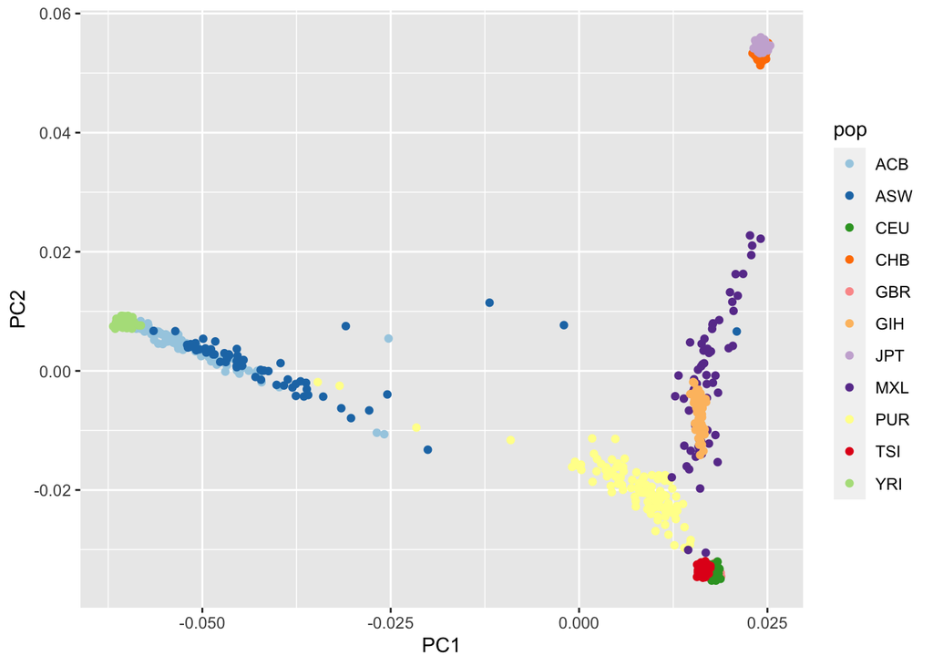

```r
ggplot(pc.df, aes(x = PC1, y = PC2)) + geom_point(aes(color = pop)) + scale_color_manual(values = pop.cols)
```

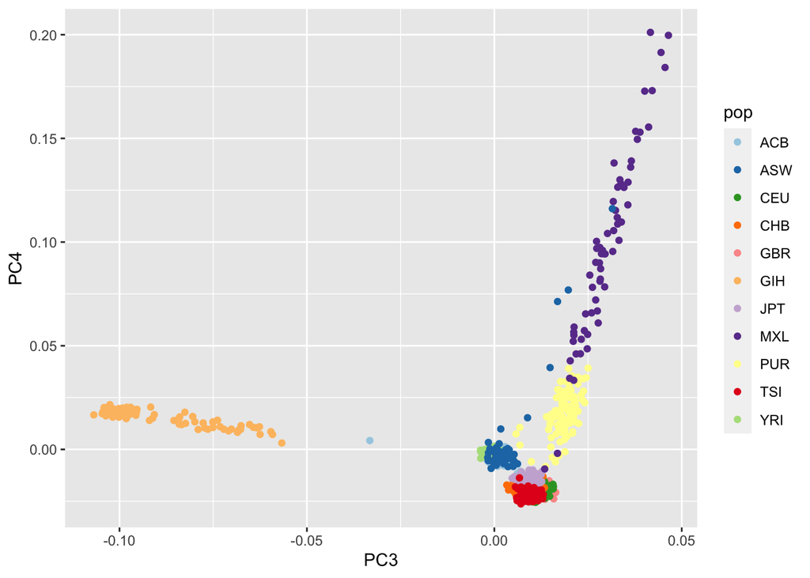

```r
ggplot(pc.df, aes(x = PC3, y = PC4)) + geom_point(aes(color = pop)) + scale_color_manual(values = pop.cols)
```

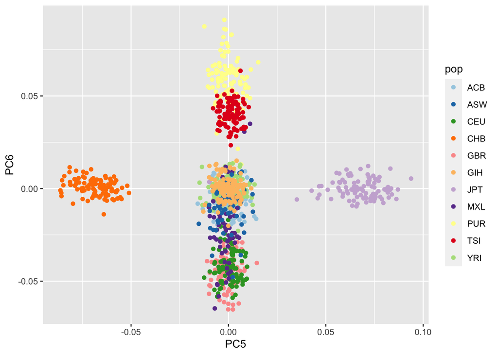

```r
ggplot(pc.df, aes(x = PC5, y = PC6)) + geom_point(aes(color = pop)) + scale_color_manual(values = pop.cols)
```

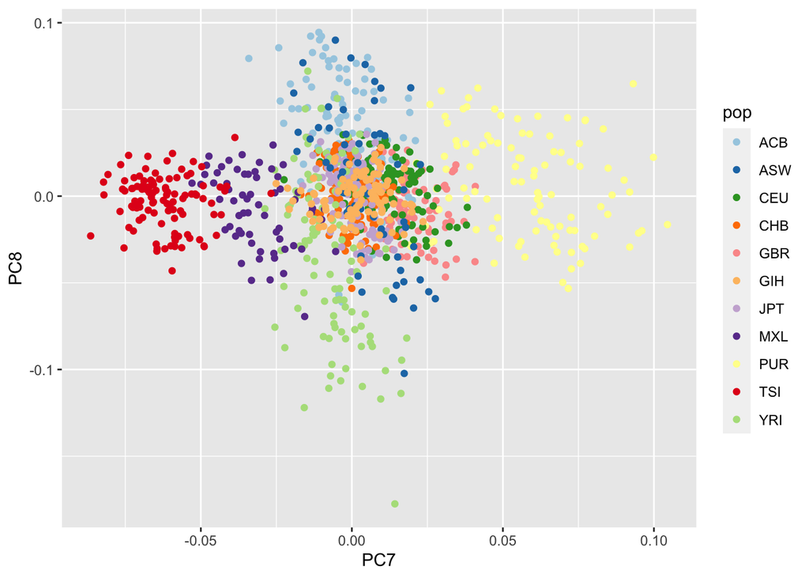

```r
ggplot(pc.df, aes(x = PC7, y = PC8)) + geom_point(aes(color = pop)) + scale_color_manual(values = pop.cols)
```

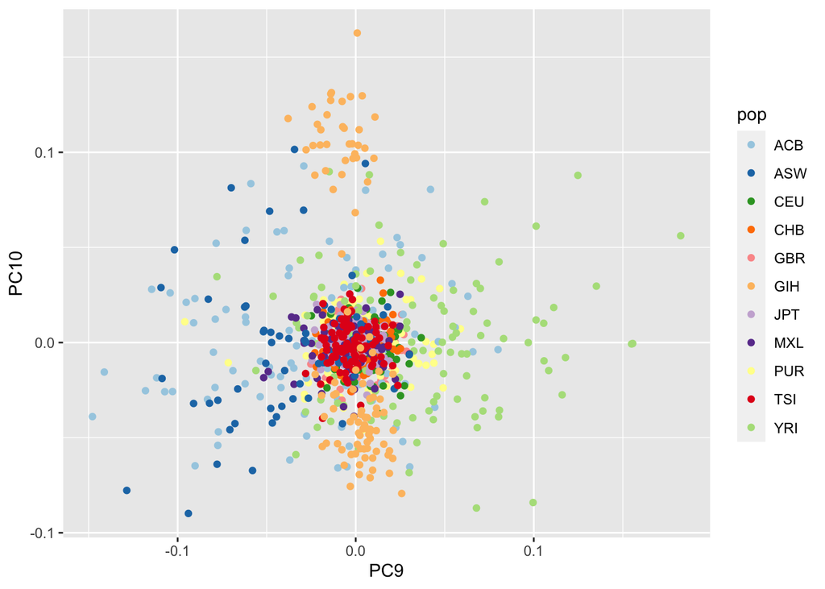

```r
ggplot(pc.df, aes(x = PC9, y = PC10)) + geom_point(aes(color = pop)) + scale_color_manual(values = pop.cols)
```

It appears as though PCs 1-7 separate the populations in our study and sufficiently capture the population structure in our sample.

### PC-Relate

The next step is [PC-Relate](http://www.ncbi.nlm.nih.gov/pubmed/26748516), which provides accurate kinship inference, even in the presence of population structure and ancestry admixture, by conditioning on ancestry informative PCs. As we saw above, PCs 1-7 separate populations in our study, so we condition on PCs 1-7 in our PC-Relate analysis. PC-Relate can be performed using the `pcrelate` function in GENESIS, which expects a `SeqVarIterator` object for the genotype data. The `training.set` argument allows for specification of which samples to use to “learn” the ancestry adjustment – we recommend the unrelated set from the PC-AiR analysis.

(NOTE: this will take a few minutes to run).

```r
seqResetFilter(gds, verbose=FALSE)
library(SeqVarTools)
seqData <- SeqVarData(gds)

# filter the GDS object to our LD-pruned variants
seqSetFilter(seqData, variant.id=pruned)
```

```
## # of selected variants: 75,743
```

```r
iterator <- SeqVarBlockIterator(seqData, verbose=FALSE)

pcrel <- pcrelate(iterator,
                  pcs=pca$vectors[,c(1:7)],
                  training.set=pca$unrels)
```

```
## Using 6 CPU cores
```

```
## 1040 samples to be included in the analysis...
```

```
## Betas for 7 PC(s) will be calculated using 1014 samples in training.set...
```

```
## Running PC-Relate analysis for 1040 samples using 75743 SNPs in 8 blocks...
```

```
## Performing Small Sample Correction...
```

```r
names(pcrel)
```

```
## [1] "kinBtwn" "kinSelf"
```

```r
# relatedness between pairs of individuals
dim(pcrel$kinBtwn)
```

```
## [1] 540280      6
```

```r
head(pcrel$kinBtwn)
```

```
##       ID1     ID2          kin        k0            k2  nsnp
## 1 HG00096 HG00097  0.001588431 0.9932987 -0.0003476095 69500
## 2 HG00096 HG00099  0.003362302 0.9932786  0.0067278300 69323
## 3 HG00096 HG00100 -0.003428617 1.0124657 -0.0012487941 69424
## 4 HG00096 HG00101  0.003034543 0.9845987 -0.0032630923 69416
## 5 HG00096 HG00102  0.004579173 0.9805721 -0.0011112225 69195
## 6 HG00096 HG00103  0.003119401 0.9766951 -0.0108272507 69195
```

```r
# self-kinship estimates
dim(pcrel$kinSelf)
```

```
## [1] 1040    3
```

```r
head(pcrel$kinSelf)
```

```
##        ID           f  nsnp
## 1 HG00096 -0.01454001 69639
## 2 HG00097 -0.01167319 69917
## 3 HG00099 -0.02335083 69572
## 4 HG00100 -0.02149244 69697
## 5 HG00101 -0.02210617 69798
## 6 HG00102 -0.01810681 69541
```

```r
# save output
save(pcrel, file="data/pcrelate.RData")
```

We plot the pairwise kinship estimates againts the IBD0 (`k0`) estimates (the proportion of variants for which the pair of individuals share 0 alleles identical by descent). We use a hexbin plot to visualize the relatedness for all pairs of samples.

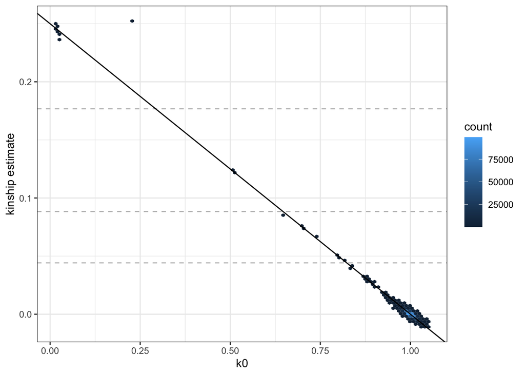

```r
ggplot(pcrel$kinBtwn, aes(k0, kin)) +
    geom_hline(yintercept=2^(-seq(5,9,2)/2), linetype="dashed", color="grey") +
    geom_hex(bins = 100) +
    geom_abline(intercept = 0.25, slope = -0.25) +
    ylab("kinship estimate") +
    theme_bw()
```

We get very similar inference for 1st and 2nd degree relatives, but we also see that the PC-Relate relatedness estimates for unrelated pairs (i.e. kin ~ 0 and k0 ~ 1) are much closer to expectation than those from KING-robust.

### Advanced Notes

In small samples (such as this one), we recommend performing a second iteration of PC-AiR and PC-Relate. Using the first iteration of PC-Relate ancestry-adjusted kinship estimates, we can often better partition our sample into unrelated and related sets, which leads to better ancestry PCs from PC-AiR and better relatedness estimates from PC-Relate. The steps to perform the second iteration are:

1. Perform a second PC-AiR analysis using the PC-Relate kinship matrix as the kinship estimates. Still use the (original) KING-robust matrix for the ancestry divergence estimates.
2. Perform a second PC-Relate analysis using the new PC-AiR PCs to adjust for population structure.

In large samples (such as TOPMed), the KING-robust and PC-Relate analyses can be very time consuming, so we suggest the following alternative procedure for deconvoluting ancestry and relatedness:

1. Use the [KING-IBDseg method](https://www.kingrelatedness.com/manual.shtml#IBDSEG) to estimate kinship for all pairs of individuals. This method uses a fast algorithm to approximate IBD segments based on identity by state and works well in the presence of ancestry admixture – in our experience, it gives very similar results to PC-Relate. The software to run KING-IBDseg uses PLINK files, but we’ve written a `KING IBDseg` application on the BioData Catalyst powered by Seven Bridges platform that will use GDS files as input (it does a conversion from GDS to PLINK).
2. Perform a PC-AiR analysis to infer population structure using the KING-IBDseg estimates as the kinship estimates and using no ancestry divergence measures (in large samples, the PC-AiR algorithm works well even without the ancestry divergence).

## Exercise 2.A.1 (Application)

Use the `LD Pruning` app on the BioData Catalyst powered by Seven Bridges platform to perform LD pruning on the example 1000 Genomes GDS files you created previously. The steps to perform this analysis are as follows:

- Copy the app to your project if it is not already there:
  - Click: Public Resources > Workflows and Tools > Browse
  - Search for `LD Pruning`
  - Click: Copy > Select your project > Copy
- Run the analysis in your project:
  - Click: Apps > `LD Pruning` > Run
  - Specify the Inputs:
    - GDS Files: `1KG_phase3_GRCh38_subset_chr<CHR>.gds` (select all 22 chromosomes)
  - Specify the App Settings:
    - Autosomes only: TRUE
    - LD |r| threshold: 0.32 ($\approx r^2 = 0.1$)
    - MAF threshold: 0.05
    - Output prefix: “1KG_phase3_GRCh38_subset” (or any other string to name the output file)
  - Click: Run

The analysis will take a few minutes to run. You can find your analysis in the Tasks menu of your Project. Use the “View stats & logs” button to check on the status of your tasks. Click on the bar that says “ld_pruning”, click “View Logs”, and click one of the “ld_pruning” folders (there’s one per chromosome). In here you can see detailed logs of the job; take a look at the `job.out.log` and `job.err.log` – these can be useful for debugging issues.

The output of this analysis will be a single file (`<output prefix>_pruned.gds`) with the genotype data from the LD pruned variants across all 22 chromosomes.

You can find the expected output of this analysis by looking at the existing task `02 LD Pruning` in the Tasks menu of your Project. The output files are available in the Project, so you do not need to wait for your analysis to finish to move to the next exercise.

## Exercise 2.A.2 (Application)

Use the `KING robust` app on the BioData Catalyst powered by Seven Bridges platform to perform a KING-robust analysis of the example 1000 Genomes data using the LD pruned variants. The steps to perform this analysis are as follows:

- Copy the app to your project if it is not already there:
  - Click: Public Resources > Workflows and Tools > Browse
  - Search for `KING robust`
  - Click: Copy > Select your project > Copy
- Run the analysis in your project:
  - Click: Apps > `KING robust` > Run
  - Specify the Inputs:
    - GDS file: `1KG_phase3_GRCh38_subset_pruned.gds` (has pruned variants from all 22 chromosomes)
  - Specify the App Settings:
    - kinship_plots > Kinship plotting threshold: 0
    - Output prefix: “1KG_phase3_GRCh38_subset” (or any other string to name the output file)
  - Click: Run

The analysis will take a few minutes to run. You can find your analysis in the Tasks menu of your Project to check on its progress and see the results once it has completed.

The output of this analysis will be a `<output_prefix>_king_robust.gds` file that has the kinship estimates and a `<output_prefix>_king_robust_all.pdf` with the plot of estimated kinship vs. IBS0. Look at the kinship plot – how many 1st degree relative pairs are identified? How many 2nd degree relative pairs are identified?

You can find the expected output of this analysis by looking at the existing task `03 King robust` in the Tasks menu of your Project. The output files are available in the Project, so you do not need to wait for your analysis to finish to move to the next exercise.

### Solution 2.A.2 (Application)

From the kinship plot, we can see that there are 6 1st degree relative pairs (5 parent-offspring; 1 full sibling) and 3 2nd degree relative pairs identified.

## Exercise 2.A.3 (Application)

Use the `PC-AiR` app on the BioData Catalyst powered by Seven Bridges platform to perform a PC-AiR analysis of the example 1000 Genomes data using the LD pruned variants. Use the KING-robust kinship estimates as both the kinship and divergence measures. The steps to perform this analysis are as follows:

- Copy the app to your project if it is not already there:
  - Click: Public Resources > Workflows and Tools > Browse
  - Search for `PC-AiR`
  - Click: Copy > Select your project > Copy
- Run the analysis in your project:
  - Click: Apps > `PC-AiR` > Run
  - Specify the Inputs:
    - Pruned GDS File: `1KG_phase3_GRCh38_subset_pruned.gds` (has pruned variants from all 22 chromosomes)
    - Kinship File: `1KG_phase3_GRCh38_subset_king_robust.gds`
    - Divergence File: `1KG_phase3_GRCh38_subset_king_robust.gds`
    - Phenotype file: `pheno_annotated.RData`
  - Specify the App Settings:
    - pca_byrel > Number of PCs: 12
    - pca_plots > Group: pop (sample variable for coloring output PCA)
    - pca_plots > Number of PCs: 12
    - PC-variant correlation > Run PC-variant correlation: FALSE (extra diagnostic step that takes a while to run)
    - Output prefix: “1KG_phase3_GRCh38_subset” (or any other string to name the output file)
  - Click: Run

The analysis will take a few minutes to run. You can find your analysis in the Tasks menu of your Project to check on its progress and see the results once it has completed.

The output of this analysis is a “_pca.RData” object with the PC values and several PC plots. Look at the parallel coordinates plot (“`<output_prefix>_parcoord.pdf`”) generated by the task. How many PCs appear to reflect population structure in the sample? This will determine how many PCs you should use to adjust PC-Relate in the next exercise.

You can find the expected output of this analysis by looking at the existing task `04 PC-AiR` in the Tasks menu of your Project. The output files are available in the Project, so you do not need to wait for your analysis to finish to move to the next exercise.

### Solution 2.A.3 (Application)

From the parallel coordinates plot, we can see that PCs 1-7 appear to reflect population structure. We will use the first 7 PCs to adjust for population structure in the PC-Relate analysis in the next exercise.

## Exercise 2.A.4 (Application)

Use the `PC-Relate` app on the BioData Catalyst powered by Seven Bridges platform to perform a PC-Relate analysis of the example 1000 Genomes data using the LD pruned variants. Use the PC-AiR PCs to adjust for population structure. The steps to perform this analysis are as follows:

- Copy the app to your project if it is not already there:
  - Click: Public Resources > Workflows and Tools > Browse
  - Search for `PC-Relate`
  - Click: Copy > Select your project > Copy
- Run the analysis in your project:
  - Click: Apps > `PC-Relate` > Run
  - Specify the Inputs:
    - GDS File: `1KG_phase3_subset_pruned.gds` (has pruned variants from all 22 chromosomes)
    - PCA file: `1KG_phase3_subset_pca.RData`
  - Specify the App Settings:
    - pcrelate_beta > Number of PCs: 7
    - pcrelate > Number of PCs: 7
    - pcrelate > Return IBD probabilities?: TRUE
    - pcrelate_correct > Sparse threshold: -1 (to keep full dense matrix)
    - kinship_plots > Kinship plotting threshold: 0
    - kinship_plots > Return IBD probabilities?: TRUE
    - Output prefix: “1KG_phase3_GRCh38_subset” (or any other string to name the output file)
  - Click: Run

The analysis will take a few minutes to run. You can find your analysis in the Tasks menu of your Project to check on its progress and see the results once it has completed.

The output of this analysis is a `<output_prefix>_pcrelate.RData` file that contains the PC-Relate relatedness estimates, a `<output_prefix>_pcrelate_Matrix.RData` file that contains a sparse matrix of kinship estimates (more on this in the Advanced GWAS tutorial), and a `<output_prefix>_pcrelate_all.pdf` with the plot of estimated kinship vs. k0. Look at the kinship plot – how many 1st degree relative pairs are identified? How many 2nd degree relative pairs are identified?

You can find the expected output of this analysis by looking at the existing task `05 PC-Relate` in the Tasks menu of your Project.

### Solution 2.A.4 (Application)

From the kinship plot, you can see that there are 6 1st degree relative pairs (5 parent-offspring; 1 full sibling) and 2 2nd degree relative pairs identified.